# Notebook

## Decision Tress

**Udacity: Intro to Machine Learning**

Chapter 4

**Note:** Since required dependencies are not available, this is just a code snippet for now (instead of executing in cell blocks).

**Finding Accuracy:**

```
import sys
from class_vis import prettyPicture
from prep_terrain_data import makeTerrainData
from sklearn import tree
from sklearn.metrics import accuracy_score

import numpy as np
import pylab as pl

features_train, labels_train, features_test, labels_test = makeTerrainData()



#################################################################################


########################## DECISION TREE #################################

def classify(features_train, labels_train):

    ### your code goes here--should return a trained decision tree classifer
    X = features_train
    Y = labels_train
    clf = tree.DecisionTreeClassifier()
    clf = clf.fit(X,Y)
    return clf

#### your code goes here
clf = classify(features_train, labels_train)


# ask classifier to predict
labels_pred = clf.predict(features_test)

acc = accuracy_score(labels_test, labels_pred)
### be sure to compute the accuracy on the test set



def submitAccuracies():
  return {"acc":round(acc,3)}
```

Output: {"message": "{'acc': 0.908}"}

**Minimum Samples (2 and 50):**

```
import sys
from class_vis import prettyPicture
from prep_terrain_data import makeTerrainData
from sklearn import tree
import matplotlib.pyplot as plt
import numpy as np
import pylab as pl
from sklearn.metrics import accuracy_score

features_train, labels_train, features_test, labels_test = makeTerrainData()



########################## DECISION TREE #################################


### your code goes here--now create 2 decision tree classifiers,
### one with min_samples_split=2 and one with min_samples_split=50
### compute the accuracies on the testing data and store
### the accuracy numbers to acc_min_samples_split_2 and
### acc_min_samples_split_50, respectively
def classify(features_train, labels_train, min_samples=2):

    ### your code goes here--should return a trained decision tree classifer
    X = features_train
    Y = labels_train
    clf = tree.DecisionTreeClassifier(min_samples_split=min_samples)
    clf = clf.fit(X,Y)
    return clf

clf_2 = classify(features_train, labels_train, 2)
clf_50 = classify(features_train, labels_train, 50)

labels_pred_2 = clf_2.predict(features_test)
labels_pred_50 = clf_50.predict(features_test)

acc_min_samples_split_2 = accuracy_score(labels_test, labels_pred_2)
acc_min_samples_split_50 = accuracy_score(labels_test, labels_pred_50)


def submitAccuracies():
  return {"acc_min_samples_split_2":round(acc_min_samples_split_2,3),
          "acc_min_samples_split_50":round(acc_min_samples_split_50,3)}
```

Output: {"message": "{'acc_min_samples_split_50': 0.912, 'acc_min_samples_split_2': 0.908}"}

## Entropy

```python
from IPython.display import YouTubeVideo
# Entropy case https://youtu.be/Bd15qhUrKCI
YouTubeVideo('Bd15qhUrKCI')
```

[video not shown]

```python
# Entrop case part 2 https://youtu.be/L6J6BRFgDiI
YouTubeVideo('L6J6BRFgDiI')
```

[video not shown]

**Entropy Calculation for below case:**

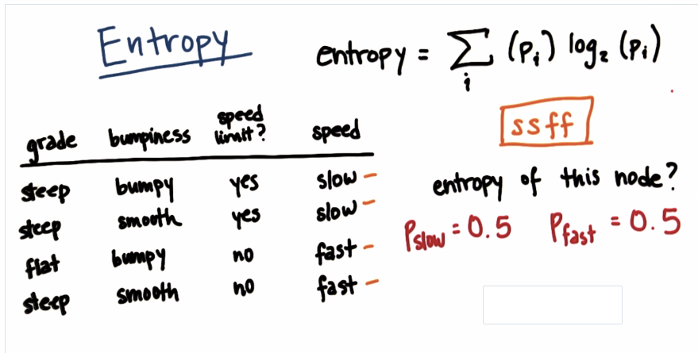

```python
from math import log

parent_entropy = -(0.5*log(0.5,2) + 0.5*log(0.5,2))  # log base 2, so 2nd argument
parent_entropy  # maximally impure
```

```
1.0
```

**Information gain - based on grade**

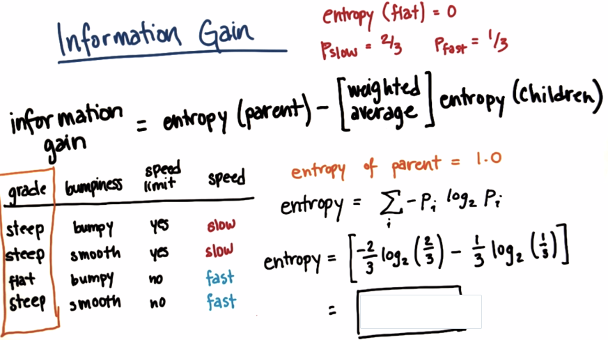

```python
child_entropy_1 = -(2/3)*log(2/3,2)-(1/3)*log(1/3,2)
child_entropy_1
```

```
0.9182958340544896
```

```python
child_entropy_2 = 0  # as its only 'f'

information_gain = parent_entropy - ( (3/4)*child_entropy_1 + (1/4)*child_entropy_2 )
information_gain
```

```
0.31127812445913283
```

**Information gain - based on bumpiness**

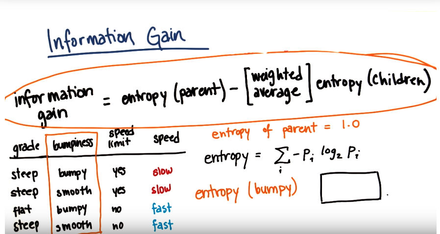

```python
from graphviz import Digraph
g = Digraph()
g.node('A','ssff',xlabel='P')
g.node('B','sf',xlabel='C1')
g.node('C','sf',xlabel='C2')
g.edge('A','B',label='bumpy')
g.edge('A','C',label='smooth')
g
```

[figure not shown]

```python
# Parent P : ssff
entropy_P = -(0.5*log(0.5,2) + 0.5*log(0.5,2))

# Child C1 : sf
entropy_C1 = -(0.5*log(0.5,2) + 0.5*log(0.5,2))

# Child C2 : sf
entropy_C2 = -(0.5*log(0.5,2) + 0.5*log(0.5,2))
```

```python
information_gain = entropy_P - ( (2/4)*entropy_C1 + (2/4)*entropy_C2 )
information_gain
```

```
0.0
```

**Information gain - based on speed limit**

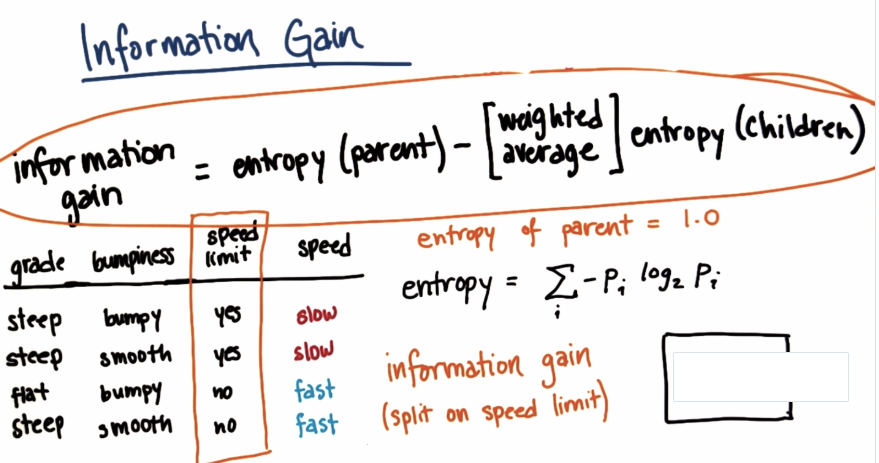

```python
from graphviz import Digraph
g = Digraph()
g.node('A','ssff',xlabel='P')
g.node('B','ss',xlabel='C1')
g.node('C','ff',xlabel='C2')
g.edge('A','B',label='Speed limit yes')
g.edge('A','C',label='Speed limit no')
g
```

[figure not shown]

```python
# Parent P : ssff
entropy_P = -(0.5*log(0.5,2) + 0.5*log(0.5,2))

# Child C1 : ss
entropy_C1 = -(1*log(1,2))

# Child C2 : ff
entropy_C2 = -(1*log(1,2))
```

```python
information_gain = entropy_P - ( (2/4)*entropy_C1 + (2/4)*entropy_C2 )
information_gain
```

```
1.0
```

## DT Mini Project

Email classification.  
Starter skeleton code is [here](https://github.com/udacity/ud120-projects/blob/master/decision_tree/dt_author_id.py)

```python
#!/usr/bin/python

"""
    This is the code to accompany the Lesson 2 (SVM) mini-project.

    Use a SVM to identify emails from the Enron corpus by their authors:
    Sara has label 0
    Chris has label 1
"""

import sys
from time import time
sys.path.append("../tools/")
from email_preprocess import preprocess
from sklearn import tree
from sklearn.metrics import accuracy_score


### features_train and features_test are the features for the training
### and testing datasets, respectively
### labels_train and labels_test are the corresponding item labels
features_train, features_test, labels_train, labels_test = preprocess()  # 10 is percentile




#########################################################
### your code goes here ###
def classify(features_train, labels_train, min_samples=2):

    ### your code goes here--should return a trained decision tree classifer
    X = features_train
    Y = labels_train
    clf = tree.DecisionTreeClassifier(min_samples_split=min_samples)

    # train the classifier
    t0 = time()
    clf = clf.fit(X,Y)
    print("Decision Tree Training time: " + str(round(time()-t0,3)) + " s")
    return clf

clf_40 = classify(features_train, labels_train, 40)

# predict
t0 = time()
labels_pred_40 = clf_40.predict(features_test)
print("Decision Tree Prediction time: " + str(round(time()-t0,3)) + " s")

# accuracy
acc_min_samples_split_40 = accuracy_score(labels_test, labels_pred_40)

print("Decision Tree Predicted labels: " + str(len(labels_pred_40)))
print("Decision Tree Accuracy: " + str(accuracy_score(labels_test, labels_pred_40)))

#########################################################
```

```
no. of Chris training emails: 7936
no. of Sara training emails: 7884
Decision Tree Training time: 66.348 s
Decision Tree Prediction time: 0.04 s
Decision Tree Predicted labels: 1758
Decision Tree Accuracy: 0.9789533560864618
```

**Speeding it up**

No of features in the data:

```python
features_train, features_test, labels_train, labels_test = preprocess()

len(features_train[0])
```

```
no. of Chris training emails: 7936
no. of Sara training emails: 7884
```

```
3785
```

After instructed by udacity mini project _"go into tools/email_preprocess.py, and find the line of code that looks like this: selector = SelectPercentile(f*classif, percentile=1) Change percentile from 10 to 1."*

ipython has to reload, which means above code also produces same result as below, so modified processor to take that as argument.

```python
from email_preprocess import preprocess
features_train, features_test, labels_train, labels_test = preprocess(percentile=1)  # now percentile = 1

len(features_train[0])
```

```
no. of Chris training emails: 7936
no. of Sara training emails: 7884
```

```
379
```

Calculating accuracy again with selector percentil as 1

```python
#!/usr/bin/python

"""
    This is the code to accompany the Lesson 2 (SVM) mini-project.

    Use a SVM to identify emails from the Enron corpus by their authors:
    Sara has label 0
    Chris has label 1
"""

import sys
from time import time
sys.path.append("../tools/")
from email_preprocess import preprocess
from sklearn import tree
from sklearn.metrics import accuracy_score


### features_train and features_test are the features for the training
### and testing datasets, respectively
### labels_train and labels_test are the corresponding item labels
features_train, features_test, labels_train, labels_test = preprocess(percentile=1)




#########################################################
### your code goes here ###
def classify(features_train, labels_train, min_samples=2):

    ### your code goes here--should return a trained decision tree classifer
    X = features_train
    Y = labels_train
    clf = tree.DecisionTreeClassifier(min_samples_split=min_samples)

    # train the classifier
    t0 = time()
    clf = clf.fit(X,Y)
    print("Decision Tree Training time: " + str(round(time()-t0,3)) + " s")
    return clf

clf_40 = classify(features_train, labels_train, 40)

# predict
t0 = time()
labels_pred_40 = clf_40.predict(features_test)
print("Decision Tree Prediction time: " + str(round(time()-t0,3)) + " s")

# accuracy
acc_min_samples_split_40 = accuracy_score(labels_test, labels_pred_40)

print("Decision Tree Predicted labels: " + str(len(labels_pred_40)))
print("Decision Tree Accuracy: " + str(accuracy_score(labels_test, labels_pred_40)))

#########################################################
```

```
no. of Chris training emails: 7936
no. of Sara training emails: 7884
Decision Tree Training time: 4.572 s
Decision Tree Prediction time: 0.016 s
Decision Tree Predicted labels: 1758
Decision Tree Accuracy: 0.9670079635949943
```

So concluding when no of features reduced, the accuracy reduced.